# COMPSCIX 415.2 Homework 9/Final

Kritika Jain

4/4/2019

```r
library(tidyverse)
library(broom)
```

## Exercise 1 - Sampling Distributions, Functions and For Loops (10 points)

Recall that the distribution of the sample mean is approximately a Normal distribution, and that the standard error is σ/√n. This holds true regardless of the distribution of our population.

For this problem, assume that the number of miles that a particular car can run before its battery wears out is exponentially distributed with an average of 10,000 miles.

The exponential distribution has a rate parameter that controls how quickly the distribution decays and defines what the mean and standard deviation will be. In our case the rate = 1/10000, the mean = 10000 and the standard deviation = 10000

### Step 1

Write an R function that does the following:

- Takes a sample of size samp_size from this exponential distribution (samp_size is an input parameter for the function)
- Calculates the mean of that sample
- Calculates the standard deviation of that sample
- Returns the calculated mean and standard deviation as a list

```r
samp_fun <- function(samp_size, samp_rate) {
  samp <- rexp(n = samp_size, rate = samp_rate)
  samp_avg = mean(samp)
  samp_std_dev = sd(samp)
  stats <- list(samp_avg = samp_avg, samp_std_dev = samp_std_dev)
  return(stats)
}
```

### Step 2

Then write a loop that does this:

- Runs the above function 1000 times, with samp_size = 50 and samp_rate = 1/10000
- Saves all of the sample means in a vector called sample_means, and all of the sample standard deviations in a vector called sample_sds

```r
sample_means <- c()
sample_sds <- c()
for(i in 1:1000){
  stats <- samp_fun(50, 1/10000)
  sample_means[i] <- stats$samp_avg
  sample_sds[i] <- stats$samp_std_dev
}
```

### Step 3

Then

- plot your sample means as a histogram

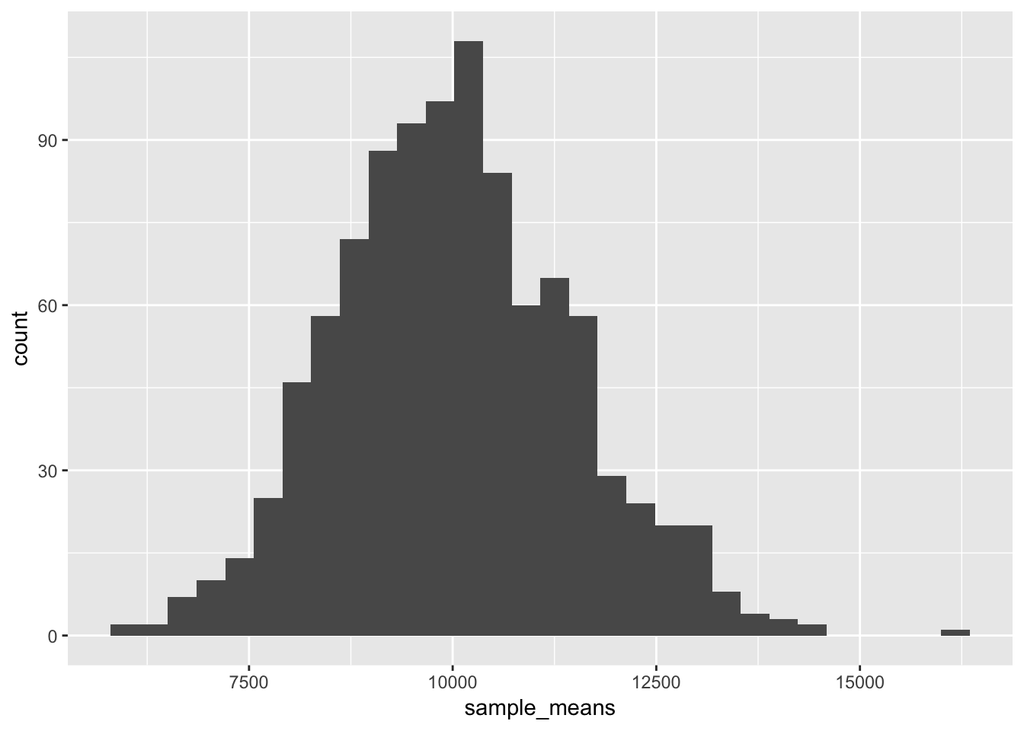

```r
sample_means_tibble <- tibble(sample_means)
sample_means_tibble %>% ggplot() + geom_histogram(aes(x = sample_means))
```

- output the standard deviation of your sample means

```r
sd(sample_means)
```

```
## [1] 1454.798
```

- calculate the theoretical standard error (σ=10000, n = sample size)

```r
st_er = 10000/sqrt(50)
st_er
```

```
## [1] 1414.214
```

- calculate the mean of the sample standard deviations and use this to calculate the empirical standard error

```r
mean_samp_sds <- mean(sample_sds)
mean_samp_sds/sqrt(50)
```

```
## [1] 1387.153
```

### Step 4

Repeat STEP 2 and STEP 3 using a sample size of 5000.

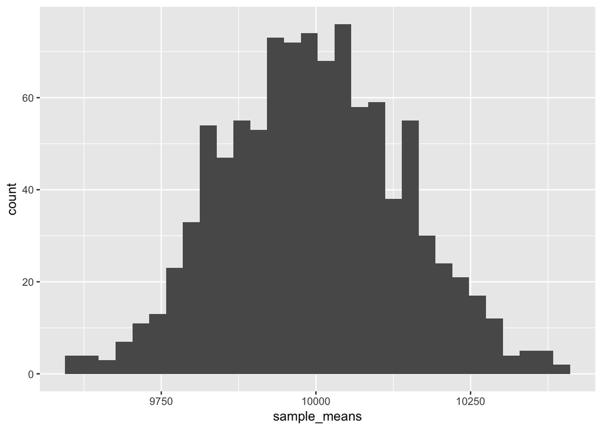

```r
#step 2
for(i in 1:1000){
  stats <- samp_fun(5000, 1/10000)
  sample_means[i] <- stats$samp_avg
  sample_sds[i] <- stats$samp_std_dev
}

# plot your sample means as a histogram
sample_means_tibble <- tibble(sample_means)
sample_means_tibble %>% ggplot() + geom_histogram(aes(x = sample_means))
```

```r
# output the standard deviation of your sample means
sd(sample_means)
```

```
## [1] 144.404
```

```r
#calculate the theoretical standard error (σ=10000, n = sample size)
st_er = 10000/sqrt(5000)
st_er
```

```
## [1] 141.4214
```

```r
#calculate the mean of the sample standard deviations and use this to calculate the empirical standard error
mean_samp_sds <- mean(sample_sds)
mean_samp_sds/sqrt(5000)
```

```
## [1] 141.3165
```

## Exercise 2 - Linear Regression (5 points)

Load the train.csv dataset into R and fit a regression model with:

- y = SalePrice
- Features: LotArea, OverallQual, and ExterQual

```r
file_path <- "/users/kritika.jain/downloads/train.csv"
train <- read_delim(file = file_path, delim = ",")
train_lm <- lm(SalePrice ~ LotArea + OverallQual + ExterQual, data = train)
train_lm
```

```
##
## Call:
## lm(formula = SalePrice ~ LotArea + OverallQual + ExterQual, data = train)
##
## Coefficients:
## (Intercept)      LotArea  OverallQual  ExterQualFa  ExterQualGd
##   40763.573        1.453    34466.192   -95352.075   -71529.493
## ExterQualTA
##  -97526.514
```

- Use the broom package to output the coefficients and the R-squared

```r
glance(train_lm)
```

```
## # A tibble: 1 x 11
##   r.squared adj.r.squared  sigma statistic p.value    df  logLik    AIC
##       <dbl>         <dbl>  <dbl>     <dbl>   <dbl> <int>   <dbl>  <dbl>
## 1     0.695         0.694 43948.      663.       0     6 -17677. 35368.
## # … with 3 more variables: BIC <dbl>, deviance <dbl>, df.residual <int>
```

- Interpret the coefficient on LotArea

For every unit LotArea goes up by, SalePrice will go up by 1.453 units. If LotArea is 0, then SalePrice is 40763.573.

- Interpret the coefficient on ExterQualGd

For every unit ExterQualGd goes up by, SalePrice will go down by 71529.493 units. If ExterQualGd is 0, then SalePrice is 40763.573.

- Compare this model to the model we fit in HW 7 with GrLivArea, OverallQual, Neighborhood. Which is the better fitting model?

I believe the model in homework 7 was better because the Rsqured and Adj Rsquared were higher.

## Exercise 3 - AB Testing (5 points)

```r
file_path <- "/users/kritika.jain/downloads/ab_test_data.csv"
abtest <- read_delim(file = file_path, delim = ",")
abtest %>% group_by(version, conversion) %>% summarize(n= n()) %>% mutate(proportion = n/4000)
```

```
## # A tibble: 4 x 4
## # Groups:   version [2]
##   version conversion     n proportion
##   <chr>        <dbl> <int>      <dbl>
## 1 A                0  1917     0.479
## 2 A                1    83     0.0208
## 3 B                0  1800     0.45
## 4 B                1   200     0.05
```

```r
#AB test
n_a <- 2000
n_b <- 2000
true_a <- 83/n_a
true_b <- 200/n_b

samp_a <- rbinom(n=1, size = n_a, prob = true_a)
samp_b <- rbinom(n=1, size = n_b, prob = true_b)

prop_test <- prop.test(c(samp_a, samp_b), c(n_a, n_b))
prop_test$p.value
```

```
## [1] 2.285337e-15
```

A. What proportion of visitors converted for each version of the webpage?

B. Perform the AB test in R. What is the p-value for the AB test (hypothesis test of proportions)?